# Math 421 - Midterm

## Instruction

The midterm has two components: the Rmarkdown notebook (html) and the presentation. We will do the presentation in class. Post both the notebook and the presentation on your Github page.

**The notebook:** The notebook should be created using `rmarkdown` or Quarto (like other assignments). The notebook should have a title.

**The Presentation:** Present your results in 5-10 minutes. To make the presentation using Rmarkdown, do the follows:

```
- In Rstudio -> File -> New File -> R markdown

- In the left panel, click to Presentation -> Click OK

- Now you have an Rmarkdown that can be knitted to be a html presentation
```

- You can also use the Rmd templates of the class slides.
- You can also use Quarto to create the presentation: *In Rstudio -> File -> New File -> Quarto Presentation…*
- You do not need to rerun all the codes for the presentation. For example, to show the model comparison, you just need to show the image of the model comparison instead of running all the models again.
- To inset an image in a slide, use `![](image.png)`
- To scale images, you can use `![](image.png){width="60%"}` or follow these below instructions.
  - https://bookdown.org/yihui/rmarkdown-cookbook/figure-size.html
  - http://zevross.com/blog/2017/06/19/tips-and-tricks-for-working-with-images-and-figures-in-r-markdown-documents/
- To turn off message and warning of a code cell, use: `{r, message=FALSE, warning=FALSE}` for the cell.

**What to present**:

- Present Part 2 - Visualization
- Present Question Question 4, 5 and 6 in Part 3.
- Present any errors/challenges you run into and how you fix/overcome them.

**Data:**

The data for the mid-term project is the Rhode Island Department of Health Hospital Discharge Data. Each row of the data presents a patient.

Link: https://drive.google.com/open?id=15QNBf6YYKocK2nNIfpKDer58kQnCPNZJ

**Notice**

- Since this is a large dataset, you could try to run the codes on the smaller dataset, which is a portion of the original dataset before running the codes on the original data. To create a random subset of the data you could use

```r
# find the number of rows of the data
n = nrow(df)

# subset 1000 rows of the data
df1 = df[sample(1:n, 1000), ]
```

## I. Data Wranggling

1. Download the data file `hdd0318cy.sas7bdat`.
2. Use `read_sas` in library `haven` to read the data.

```r
library(haven)
library(dplyr)
library(readr)
setwd("C:/Users/student/Desktop/New folder/math_421")
df <- read_sas("hdd0318cy.sas7bdat")
```

3. Filter the data to have only patients of the year 2018 (`yod=18`)

```r
df <- df %>% filter(yod == 18)
```

4. Select to work with only following variables:

```r
                      "yod", "payfix","pay_ub92","age",
                      "sex","raceethn","provider","moa",
                      "yoa","mod","admtype", "asource" ,
                      "preopday" ,"los", "service" , "icu","ccu",
                      "dispub92", "payer"  ,"drg","trandb",
                      "randbg","randbs","orr", "anes","seq",
                      "lab","dtest", "ther","blood","phar",
                      "other","patcon","bwght","total","tot" ,
                      "ecodub92","b_wt","pt_state","diag_adm","ancilar" ,
                      "campus","er_fee","er_chrg","er_mode","obs_chrg",
                      "obs_hour","psycchrg","nicu_day"
```

```r
df <- df %>%
  select(
    yod, payfix, pay_ub92, age, sex, raceethn, provider, moa, yoa, mod,
    admtype, asource, preopday, los, service, icu, ccu, dispub92, payer, drg,
    trandb, randbg, randbs, orr, anes, seq, lab, dtest, ther, blood, phar, other,
    patcon, bwght, total, tot, ecodub92, b_wt, pt_state, diag_adm, ancilar, campus,
    er_fee, er_chrg, er_mode, obs_chrg, obs_hour, psycchrg, nicu_day
  )
write_csv(df, "midterm.csv")
```

*Notice*: You may want to save the current data to your computer for easy access later. To save the data file use `write_csv(df, 'midterm.csv')`, for example. Also notice that, empty values in the data before writing to csv may turn to NAs later when you re-read the file.

5. What are variables that have missing values?

```r
missing_vars <- colnames(df)[colSums(is.na(df)) > 0]
missing_vars
```

```
## [1] "payfix"   "preopday" "obs_hour" "nicu_day"
```

6. Remove all variables with missing values.

```r
df <- df %>% select(where(~ all(!is.na(.))))
```

7. Refer to the data description in the file `HDD2015-18cy6-20-19.docx`, which variable recording the month of admission?, which variable recording the month of discharge?

```r
## MOA- month of admission
## MOD- month of discharge
```

```r
most_patients_month <- df %>%
  count(moa) %>%
  arrange(desc(n)) %>%
  slice(1)
cat("Month with the most patients:", most_patients_month$moa, "\n")
```

```
## Month with the most patients: 10
```

```r
teen_female_month <- df %>%
  filter(sex == "F", age >= 13, age <= 19) %>%
  count(moa) %>%
  arrange(desc(n)) %>%
  slice(1)

cat("Month with the most teenage female patients:", teen_female_month$moa, "\n")
```

```
## Month with the most teenage female patients:
```

```r
october_female_provider <- df %>%
  filter(sex == "F", moa == 10) %>%
  count(provider) %>%
  arrange(desc(n)) %>%
  slice(1)

cat("Provider with the most female patients in October:", october_female_provider$provider, "\n")
```

```
## Provider with the most female patients in October:
```

```r
avg_age_comparison <- df %>%
  group_by(sex) %>%
  summarise(avg_age = mean(age, na.rm = TRUE))

cat("Average age of females:", avg_age_comparison$avg_age[avg_age_comparison$sex == "F"], "\n")
```

```
## Average age of females:
```

```r
cat("Average age of males:", avg_age_comparison$avg_age[avg_age_comparison$sex == "M"], "\n")
```

```
## Average age of males:
```

12. Calculate the average age of patients by months. Which month has the oldest patients on average age?

```r
avg_age_by_month <- df %>%
  group_by(moa) %>%
  summarise(avg_age = mean(age, na.rm = TRUE)) %>%
  arrange(desc(avg_age))

oldest_month <- avg_age_by_month %>%
  slice(1)

cat("Month with the oldest patients on average age:", oldest_month$moa, "\n")
```

```
## Month with the oldest patients on average age: 1
```

```r
cat("Average age in that month:", oldest_month$avg_age, "\n")
```

```
## Average age in that month: 51.79229
```

13. What is the name of the provider that has the highest total charge?

```r
highest_charge_provider <- df %>%
  group_by(provider) %>%
  summarise(total_charge = sum(tot, na.rm = TRUE)) %>%
  arrange(desc(total_charge)) %>%
  slice(1)

cat("Provider with the highest total charge:", highest_charge_provider$provider, "\n")
```

```
## Provider with the highest total charge: 7205
```

```r
cat("Total charge for this provider:", highest_charge_provider$total_charge, "\n")
```

```
## Total charge for this provider: 1788373499
```

```r
least_charge_teen_males <- df %>%
  filter(sex == "M", age >= 13, age <= 19) %>%
  group_by(provider) %>%
  summarise(avg_charge = mean(tot, na.rm = TRUE)) %>%
  arrange(avg_charge) %>%
  slice(1)

cat("Provider with the least average total charge for teenage males:", least_charge_teen_males$provider, "\n")
```

```
## Provider with the least average total charge for teenage males:
```

```r
cat("Average total charge for this provider:", least_charge_teen_males$avg_charge, "\n")
```

```
## Average total charge for this provider:
```

15. Create a season (Spring, Summer, Fall, Winter) variable. Calculate the length of stays by season. Which season has the longest length of stays on average?

```r
df <- df %>%
  mutate(
    season = case_when(
      moa %in% c(3, 4, 5) ~ "Spring",
      moa %in% c(6, 7, 8) ~ "Summer",
      moa %in% c(9, 10, 11) ~ "Fall",
      moa %in% c(12, 1, 2) ~ "Winter"
    )
  )

length_of_stay_by_season <- df %>%
  group_by(season) %>%
  summarise(avg_length_of_stay = mean(los, na.rm = TRUE)) %>%
  arrange(desc(avg_length_of_stay))

longest_stay_season <- length_of_stay_by_season %>%
  slice(1)

cat("Season with the longest length of stays on average:", longest_stay_season$season, "\n")
```

```
## Season with the longest length of stays on average: Summer
```

```r
cat("Average length of stay during this season:", longest_stay_season$avg_length_of_stay, "\n")
```

```
## Average length of stay during this season: 4.958205
```

```r
fall_20_male_charge <- df %>%
  filter(age == 20, sex == "M", season == "Fall") %>%
  summarise(avg_daily_charge = mean(tot / los, na.rm = TRUE))

cat("Average charge for a 20-year-old male for 1 day in the Fall season:", fall_20_male_charge$avg_daily_charge, "\n")
```

```
## Average charge for a 20-year-old male for 1 day in the Fall season: NaN
```

## II. Data Visualization

Continue with the data from part I.

1. Provides at least 10 meaningful plots. Comments on the plots. All plots should have title, caption, appropriate labels on x and y-axis

```r
library(ggplot2)
library(gganimate)
library(dplyr)
```

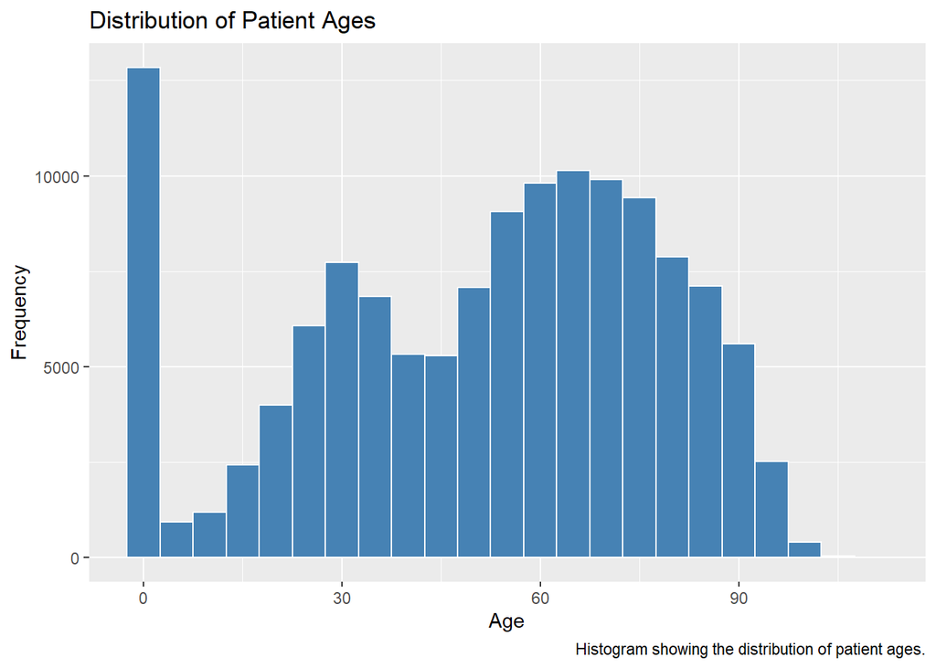

```r
## 1. Distribution of Patient Ages
ggplot(df, aes(x = age)) +
  geom_histogram(binwidth = 5, fill = "steelblue", color = "white") +
  labs(
    title = "Distribution of Patient Ages",
    x = "Age",
    y = "Frequency",
    caption = "Histogram showing the distribution of patient ages."
  )
```

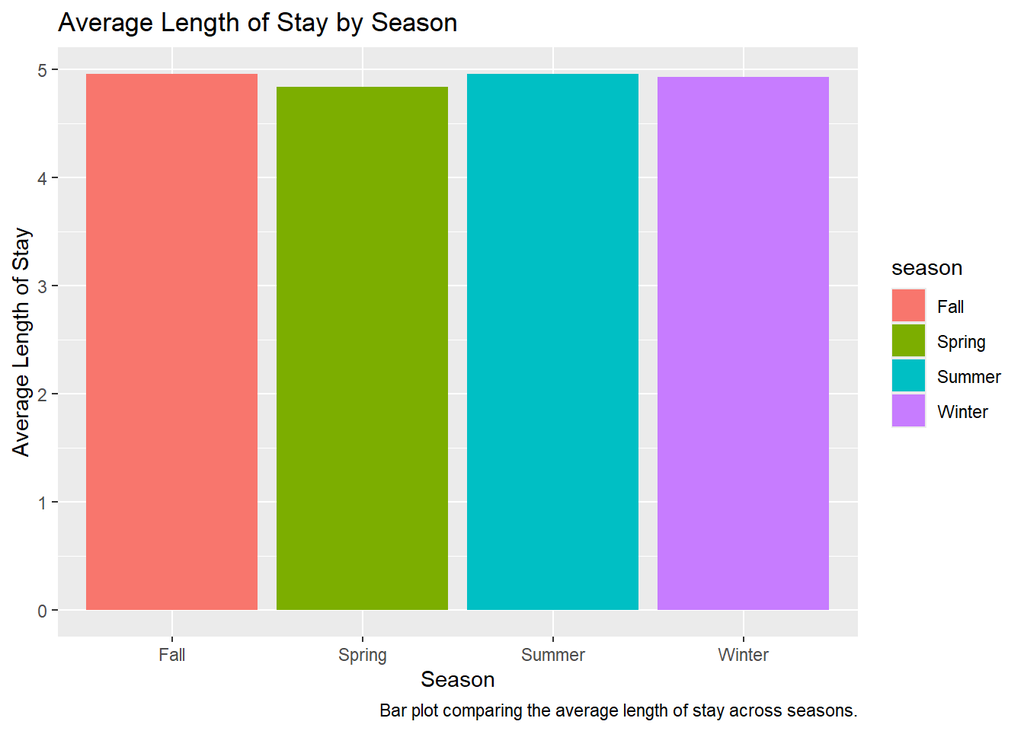

```r
## 2. Average Length of Stay by Season
df %>%
  group_by(season) %>%
  summarise(avg_los = mean(los, na.rm = TRUE)) %>%
  ggplot(aes(x = season, y = avg_los, fill = season)) +
  geom_bar(stat = "identity") +
  labs(
    title = "Average Length of Stay by Season",
    x = "Season",
    y = "Average Length of Stay",
    caption = "Bar plot comparing the average length of stay across seasons."
  )
```

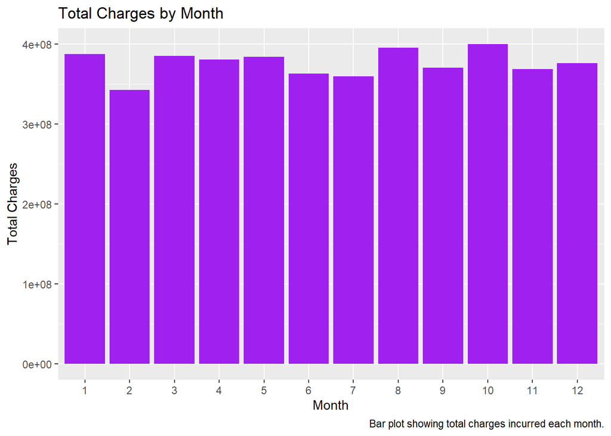

```r
## 3. Total Charges by Month
df %>%
  group_by(moa) %>%
  summarise(total_charges = sum(tot, na.rm = TRUE)) %>%
  ggplot(aes(x = factor(moa), y = total_charges)) +
  geom_col(fill = "purple") +
  labs(
    title = "Total Charges by Month",
    x = "Month",
    y = "Total Charges",
    caption = "Bar plot showing total charges incurred each month."
  )
```

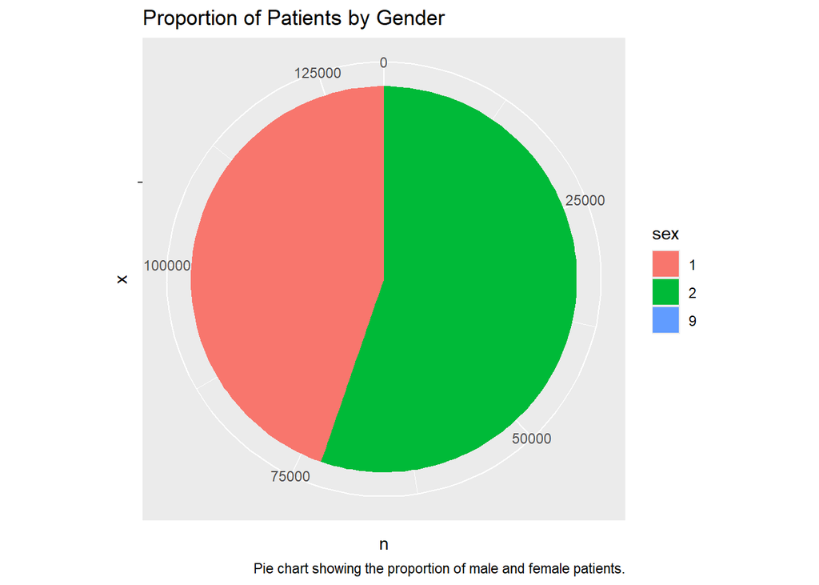

```r
## 4. Gender Proportion
df %>%
  count(sex) %>%
  ggplot(aes(x = "", y = n, fill = sex)) +
  geom_bar(stat = "identity", width = 1) +
  coord_polar("y") +
  labs(
    title = "Proportion of Patients by Gender",
    caption = "Pie chart showing the proportion of male and female patients."
  )
```

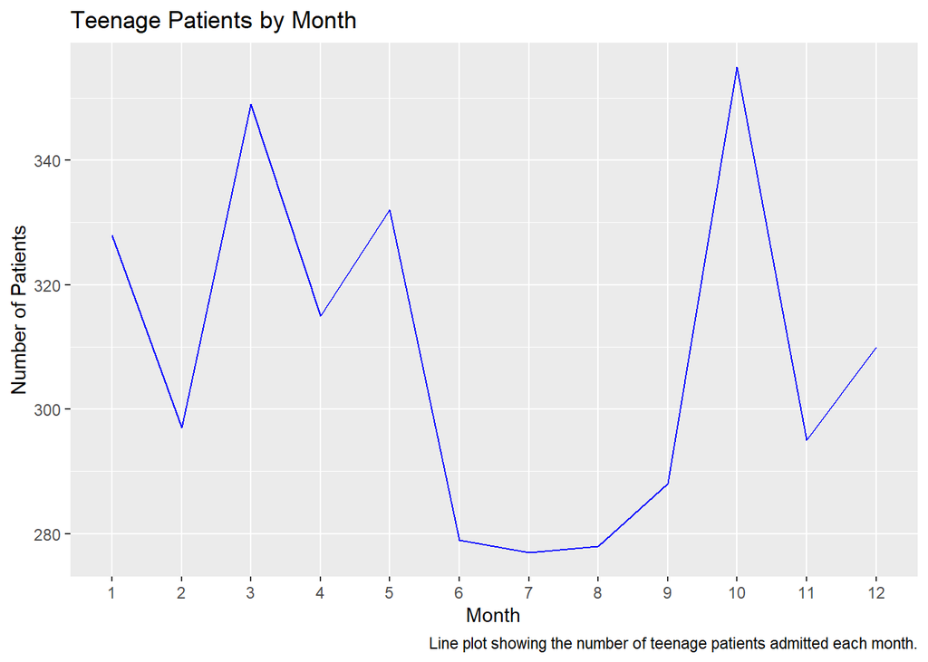

```r
## 5. Teenage Patients by Month
df %>%
  filter(age >= 13 & age <= 19) %>%
  count(moa) %>%
  ggplot(aes(x = factor(moa), y = n)) +
  geom_line(group = 1, color = "blue") +
  labs(
    title = "Teenage Patients by Month",
    x = "Month",
    y = "Number of Patients",
    caption = "Line plot showing the number of teenage patients admitted each month."
  )
```

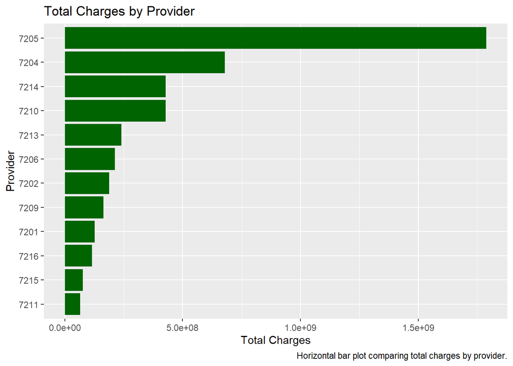

```r
## 6. Total Charges by Provider
df %>%
  group_by(provider) %>%
  summarise(total_charges = sum(tot, na.rm = TRUE)) %>%
  ggplot(aes(x = reorder(provider, total_charges), y = total_charges)) +
  geom_col(fill = "darkgreen") +
  coord_flip() +
  labs(
    title = "Total Charges by Provider",
    x = "Provider",
    y = "Total Charges",
    caption = "Horizontal bar plot comparing total charges by provider."
  )
```

[figure not shown]

```r
## 7. ICU Patients by Month
df %>%
  filter(icu == 1) %>%
  count(moa) %>%
  ggplot(aes(x = factor(moa), y = n)) +
  geom_bar(stat = "identity", fill = "red") +
  labs(
    title = "ICU Patients by Month",
    x = "Month",
    y = "Number of ICU Patients",
    caption = "Bar plot showing the number of ICU patients admitted each month."
  )
```

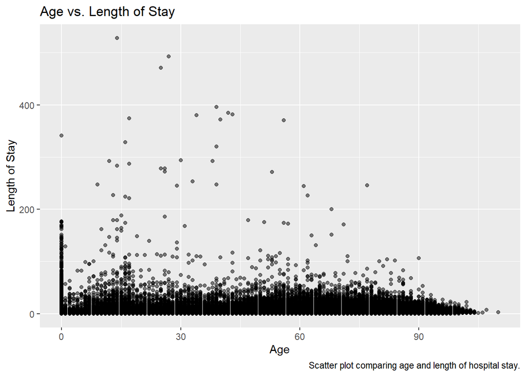

```r
## 8. Age vs. Length of Stay
ggplot(df, aes(x = age, y = los)) +
  geom_point(alpha = 0.5) +
  labs(
    title = "Age vs. Length of Stay",
    x = "Age",
    y = "Length of Stay",
    caption = "Scatter plot comparing age and length of hospital stay."
  )
```